```python
from google.colab import drive
drive.mount('/content/drive')
%cd /content/drive/MyDrive/ColabNotebooks
```

```
/content/drive/MyDrive/ColabNotebooks
```

# Introduction and Background

**Disability and Public Health** by Jackson Scrimpshire and Nikhil Modayur. [The GitHub repository can be found here](https:///github.com/jscrimpshire/CMPS3160Project). The [live site can be found here](https://jscrimpshire.github.io/CMPS3160Project/)

**Description of Project**:

This project will seek to understand questions related to the DHDS database collected by the CDC, and assess possible correlations with other public health datasets including tobacco usage. Possible questions that will be investigated include:

- What is the percentage of adults with disabilities in each state?
- What is the percentage of adults with specific functional disability types in each state?
- How does the percentage of adults with disabilities vary by age, sex, and race/ethnicity in each state?
- How does the state percentage compare with the national percentage? With percentages in neighboring states?
- Does the percentage of adults with key health indicators, such as obesity, physical activity and smoking vary across different functional disability types? Among adults with and without disabilities?

**Datasources**:

1. [DHDS - Prevalence of Disability Status and Types](https://data.cdc.gov/Disability-Health/DHDS-Prevalence-of-Disability-Status-and-Types/s2qv-b27b/about_data). Disability and Health Data System (DHDS) is an online source of state-level data on adults with disabilities. Users can access information on six functional disability types: cognitive (serious difficulty concentrating, remembering or making decisions), hearing (serious difficulty hearing or deaf), mobility (serious difficulty walking or climbing stairs), vision (serious difficulty seeing), self-care (difficulty dressing or bathing) and independent living (difficulty doing errands alone).
2. [BRFSS Prevalence and Trends Data: Tobacco Use - Four Level Smoking Data for 1995-2010](https://data.cdc.gov/Smoking-Tobacco-Use/BRFSS-Prevalence-and-Trends-Data-Tobacco-Use-Four-/8zak-ewtm/about_data)

**Collaboration Plan**: We have a shared Google Colab and GitHub where we will push our code to each other. We will also coordinate via text messages and in person meetings when needed. At minimum, we will touch base regarding the project once a week.

**Project Goals**:

1. Create a regression model that will predict the smoking values in future years
2. Quantify relationships between disability status and health behaviors (smoking, physical activity, obesity) through hypothesis testing and regression models.
3. Create interactive visualizations of disability prevalence across states
4. Build predictive models to determine which demographic factors (age, sex, race/ethnicity) are most strongly associated with different disability types across states.

# Cloning Github Repository and Importing Libraries

```python
#Clone the github repository
!git clone https://github.com/jscrimpshire/CMPS3160Project.git

#Identify the data folder of the repository
%cd /content/CMPS3160Project/data
```

```
fatal: destination path 'CMPS3160Project' already exists and is not an empty directory.
/content/CMPS3160Project/data
```

```python
!pip install geopandas mapclassify
```

```python
#Import necessary libraries
import pandas as pd
import numpy as np
import matplotlib.pyplot as plt
import statsmodels.api as sm
import seaborn as sns
import geopandas as gpd
from matplotlib.colors import LinearSegmentedColormap
from sklearn.linear_model import LinearRegression
from sklearn.preprocessing import OneHotEncoder
```

# Dataset 1: Tobacco Use from 1995-2010

```python
#Import the dataset as a csv and name it Tobacco
tobacco = pd.read_csv('BRFSS_Prevalence_and_Trends_Data__Tobacco_Use_-_Four_Level_Smoking_Data_for_1995-2010_20250313.csv')

#Take a peek at the data
tobacco.head()
```

|  | Year | State | Smoke everyday | Smoke some days | Former smoker | Never smoked | Location 1 |
| --- | --- | --- | --- | --- | --- | --- | --- |
| 0 | 1996 | Puerto Rico | 9.4 | 5.1 | 16.0 | 69.5 | Puerto Rico |
| 1 | 2005 | Virgin Islands | 5.3 | 2.8 | 12.8 | 79.1 | Virgin Islands |
| 2 | 2005 | Puerto Rico | 7.9 | 5.2 | 16.9 | 70.0 | Puerto Rico |
| 3 | 2002 | Virgin Islands | 7.0 | 2.4 | 12.1 | 78.5 | Virgin Islands |
| 4 | 2003 | Guam | 26.3 | 7.8 | 14.3 | 51.7 | NaN |

```python
#Sort the data by the percentage of people who smoke everyday in descending order
tobacco = tobacco.sort_values(by="Smoke everyday", ascending=False)
tobacco.head()

#Notice that the top five is all Kentucky. lol
```

|  | Year | State | Smoke everyday | Smoke some days | Former smoker | Never smoked | Location 1 |
| --- | --- | --- | --- | --- | --- | --- | --- |
| 127 | 2002 | Kentucky | 29.1 | 3.5 | 22.0 | 45.5 | Kentucky\n(37.645969999815804, -84.77496999996... |
| 551 | 1998 | Kentucky | 28.0 | 2.8 | 22.9 | 46.3 | Kentucky\n(37.645969999815804, -84.77496999996... |
| 368 | 1996 | Kentucky | 27.9 | 3.8 | 23.2 | 45.2 | Kentucky\n(37.645969999815804, -84.77496999996... |
| 491 | 1997 | Kentucky | 27.6 | 3.1 | 23.5 | 45.8 | Kentucky\n(37.645969999815804, -84.77496999996... |
| 185 | 2000 | Kentucky | 26.8 | 3.7 | 23.0 | 46.5 | Kentucky\n(37.645969999815804, -84.77496999996... |

```python
#Sort the data by the percentage of people who smoke everyday in ascending order
tobacco = tobacco.sort_values(by="Smoke everyday", ascending=True)
tobacco.head()

#Virgin Islands do not mess with smoking
```

|  | Year | State | Smoke everyday | Smoke some days | Former smoker | Never smoked | Location 1 |
| --- | --- | --- | --- | --- | --- | --- | --- |
| 292 | 2010 | Virgin Islands | 3.6 | 2.2 | 10.5 | 83.7 | (18.3333, -64.8333) |
| 429 | 2009 | Virgin Islands | 3.9 | 2.6 | 11.1 | 82.5 | (18.3333, -64.8333) |
| 120 | 2008 | Virgin Islands | 4.1 | 2.3 | 11.5 | 82.1 | Virgin Islands |
| 1 | 2005 | Virgin Islands | 5.3 | 2.8 | 12.8 | 79.1 | Virgin Islands |
| 617 | 2007 | Virgin Islands | 5.6 | 3.0 | 11.9 | 79.5 | Virgin Islands |

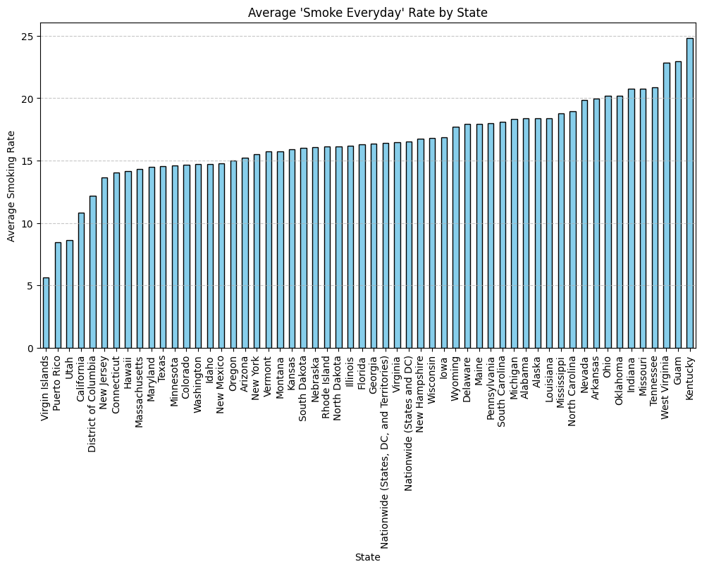

```python
# Group by State and calculate the mean of 'Smoke everyday'
state_avg_smoking = tobacco.groupby('State')['Smoke everyday'].mean().sort_values()

# Plot bar chart
plt.figure(figsize=(12, 6))
state_avg_smoking.plot(kind='bar', color='skyblue', edgecolor='black')

# Customize plot
plt.xlabel("State")
plt.ylabel("Average Smoking Rate")
plt.title("Average 'Smoke Everyday' Rate by State")
plt.xticks(rotation=90)  # Rotate x-axis labels for readability
plt.grid(axis='y', linestyle='--', alpha=0.7)

# Show plot
plt.show()
```

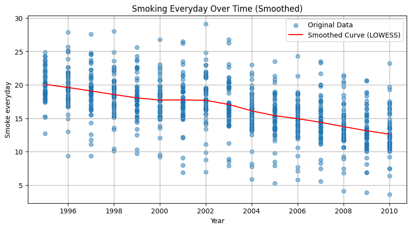

```python
#Sort by Year
tobacco = tobacco.sort_values(by='Year')

# Apply LOWESS smoothing
lowess = sm.nonparametric.lowess(tobacco['Smoke everyday'], tobacco['Year'], frac=0.2)  # Adjust frac for smoothness

# Plot original data
plt.figure(figsize=(10, 5))
plt.scatter(tobacco['Year'], tobacco['Smoke everyday'], label='Original Data', alpha=0.5)
plt.plot(lowess[:, 0], lowess[:, 1], color='red', label='Smoothed Curve (LOWESS)')
plt.xlabel('Year')
plt.ylabel('Smoke everyday')
plt.title('Smoking Everyday Over Time (Smoothed)')
plt.legend()
plt.grid(True)
plt.show()
```

# Dataset 2: DHDS - Prevalence of Disability Status and Types

```python
# Import and name dhds dataset
dhds = pd.read_csv('../data/DHDS_-_Prevalence_of_Disability_Status_and_Types_20250313.csv')
dhds.head()
```

|  | Year | LocationAbbr | LocationDesc | DataSource | Category | Indicator | Response | Data_Value_Unit | Data_Value_Type | Data_Value | ... | Stratification2 | CategoryID | IndicatorID | LocationID | ResponseID | DataValueTypeID | StratificationCategoryID1 | StratificationID1 | StratificationCategoryID2 | StratificationID2 |
| --- | --- | --- | --- | --- | --- | --- | --- | --- | --- | --- | --- | --- | --- | --- | --- | --- | --- | --- | --- | --- | --- |
| 0 | 2022 | NJ | New Jersey | BRFSS | Disability Estimates | Disability status and types among adults 18 ye... | Cognitive Disability | % | Age-adjusted Prevalence | 10.4 | ... | NaN | DISEST | STATTYPE | 34 | Q6COG | AGEADJPREV | CAT1 | BO1 | NaN | NaN |
| 1 | 2022 | WI | Wisconsin | BRFSS | Disability Estimates | Disability status and types among adults 18 ye... | Cognitive Disability | % | Age-adjusted Prevalence | 13.9 | ... | NaN | DISEST | STATTYPE | 55 | Q6COG | AGEADJPREV | CAT1 | BO1 | NaN | NaN |
| 2 | 2022 | OH | Ohio | BRFSS | Disability Estimates | Disability status and types among adults 18 ye... | Self-care Disability | % | Age-adjusted Prevalence | 3.8 | ... | NaN | DISEST | STATTYPE | 39 | Q6SEL | AGEADJPREV | CAT1 | BO1 | NaN | NaN |
| 3 | 2022 | AR | Arkansas | BRFSS | Disability Estimates | Disability status and types among adults 18 ye... | Self-care Disability | % | Age-adjusted Prevalence | 5.4 | ... | NaN | DISEST | STATTYPE | 5 | Q6SEL | AGEADJPREV | CAT1 | BO1 | NaN | NaN |
| 4 | 2022 | DE | Delaware | BRFSS | Disability Estimates | Disability status and types among adults 18 ye... | No Disability | % | Age-adjusted Prevalence | 74.9 | ... | NaN | DISEST | STATTYPE | 10 | Q6DIS2 | AGEADJPREV | CAT1 | BO1 | NaN | NaN |

5 rows × 30 columns

```python
print(f"Dataset shape: {dhds.shape}")
```

```
Dataset shape: (3592, 30)
```

## Ranking Based on Cognitive Disability Percentage

```python
# Filter for disability type
cognitive = dhds[dhds['Response'] == 'Cognitive Disability']

# Sort states by disability rate
cognitive_by_state = cognitive.sort_values('Data_Value', ascending=False)

# Show top 5
print("States with highest cognitive disability rates:")
print(cognitive_by_state[['LocationDesc', 'Data_Value']].head(5))
```

```
States with highest cognitive disability rates:
       LocationDesc  Data_Value
255        Arkansas        19.9
2042  West Virginia        19.6
383   West Virginia        19.3
30        Louisiana        19.3
2599  West Virginia        19.1
```

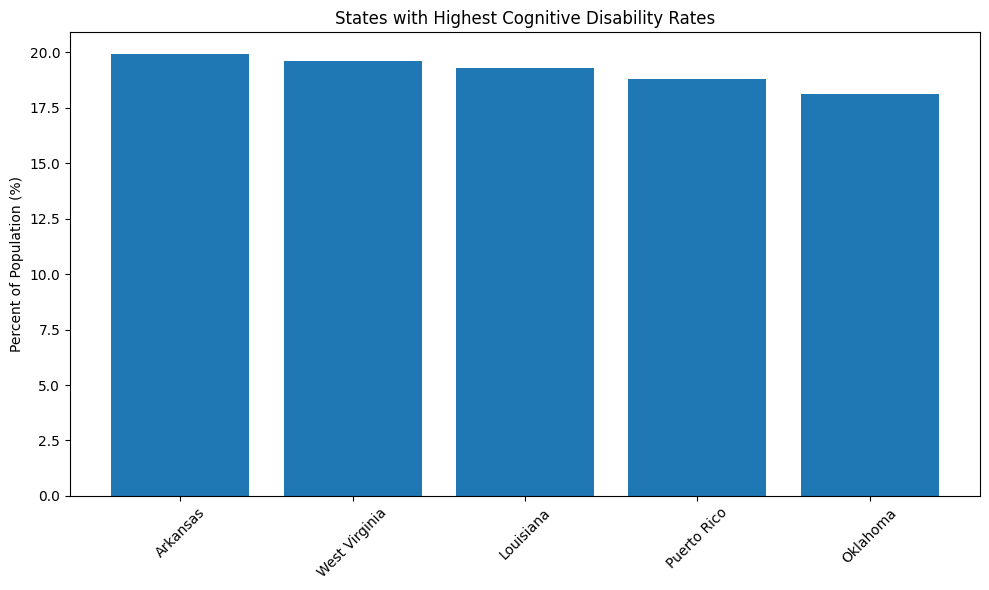

```python
# Show bar chart
top_states = cognitive_by_state.head(10)
plt.figure(figsize=(10, 6))
plt.bar(top_states['LocationDesc'], top_states['Data_Value'])
plt.xticks(rotation=45)
#title the bar chart
plt.title('States with Highest Cognitive Disability Rates')
#set the y axis label
plt.ylabel('Percent of Population (%)')
plt.tight_layout()
plt.show()
```

## 2022 Data Analysis

```python
# Get 2022 data
latest_year = dhds['Year'].max()

# Define common disability types
disability_types = [
    'Cognitive Disability',
    'Hearing Disability',
    'Mobility Disability',
    'Vision Disability',
    'Self-care Disability',
    'Independent Living Disability',
    'Any Disability'
]

# Calculate averages
type_prevalence = []
for disability in disability_types:
    data = dhds[(dhds['Response'] == disability) & (dhds['Year'] == latest_year)]
    avg = data['Data_Value'].mean()
    type_prevalence.append({'Type': disability, 'Prevalence': avg})

# Convert to df anbd sort
type_df = pd.DataFrame(type_prevalence).sort_values('Prevalence', ascending=False)

# Display output
print("Average Prevalence by Disability Type:")
print(type_df)
```

```
Average Prevalence by Disability Type:
                            Type  Prevalence
6                 Any Disability   28.860000
0           Cognitive Disability   14.064615
2            Mobility Disability   12.150769
5  Independent Living Disability    7.617188
1             Hearing Disability    6.472308
3              Vision Disability    5.432308
4           Self-care Disability    3.500000
```

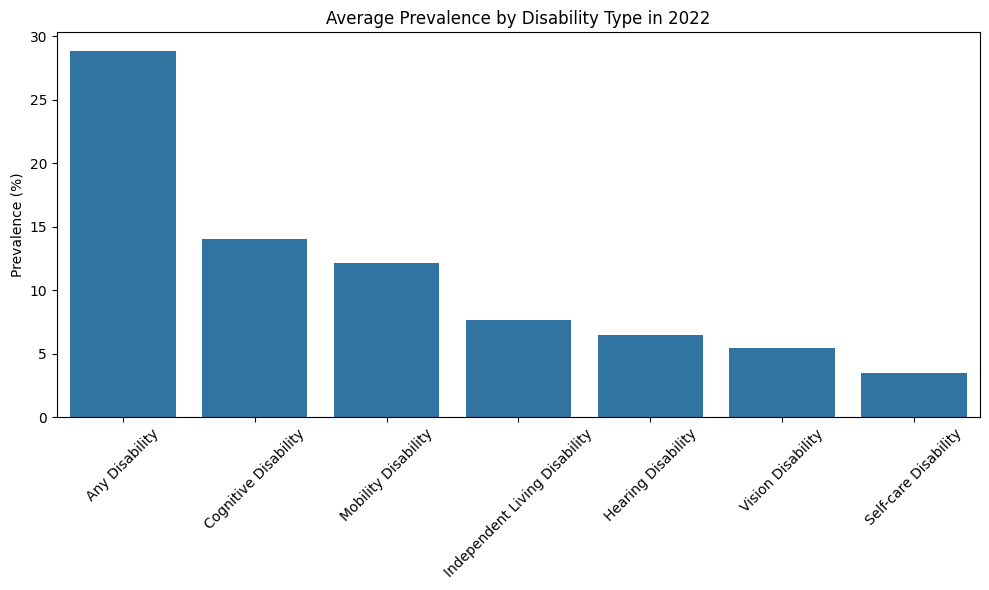

```python
# Create bar chart
plt.figure(figsize=(10, 6))
sns.barplot(x='Type', y='Prevalence', data=type_df)
plt.title('Average Prevalence by Disability Type in 2022')
plt.xlabel('')
plt.ylabel('Prevalence (%)')
plt.xticks(rotation=45)
plt.tight_layout()
plt.savefig('disability_by_type.png')
```

## Geographic Analysis

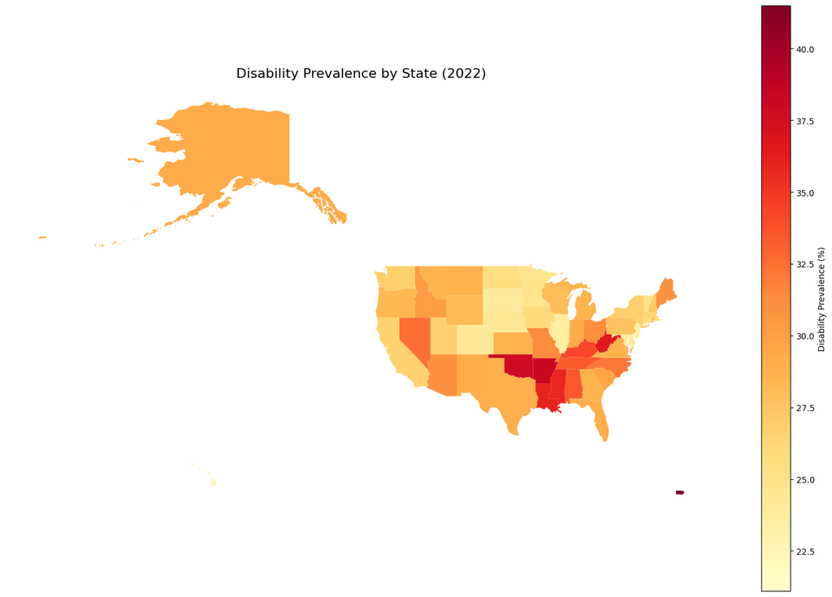

```python
# Filter for 'Any Disability' in 2022
state_data = dhds[(dhds['Response'] == 'Any Disability') & (dhds['Year'] == latest_year)]
state_rates = state_data.groupby('LocationDesc')['Data_Value'].mean()

# Download US states from geopandas
usa = gpd.read_file('https://raw.githubusercontent.com/PublicaMundi/MappingAPI/master/data/geojson/us-states.json')

# Create df names and rate values
map_data = pd.DataFrame({
    'state_name': state_rates.index,
    'disability_rate': state_rates.values
})

# Merge the datasets
merged = usa.merge(map_data, left_on='name', right_on='state_name', how='left')

fig, ax = plt.subplots(1, 1, figsize=(15, 10))

# Plot states with data
merged.plot(
    column='disability_rate',
    ax=ax,
    legend=True,
    cmap='YlOrRd',
    missing_kwds={'color': 'lightgray'},
    legend_kwds={'label': 'Disability Prevalence (%)'}
)

plt.title(f'Disability Prevalence by State ({latest_year})', fontsize=16)
plt.axis('off')
plt.tight_layout()
```

# Building Models

Now it's time to build our model! We want to examine the relationship between year and state and smoker characteristics. We have a few different options when we are trying to predict the smoker characteristics based on the year/state inputs.

We initially tried to use linear and polynomial regression, but we ran into a major problem: these models can predict values outside of our range (0-100%)! Obviously, we cannot have (for example) -4.7% of people who have never smoked, so we had to change strategies.

We decided to use a logistic regression on logit-transformed data with polynomial year terms for the following reasons:

1. Linear regression models predict values anywhere from −∞ to +∞, which is problematic for percentages. By applying the logit transformation to percentages (rescaling from [0, 100] → [0, 1] → (−∞, +∞)), we can:
- Fit a linear model on the log-odds scale (unbounded)
- Then transform predictions back using the inverse logit, ensuring values stay in the [0, 1] range
- Multiply by 100 to return to percentage scale
2. We can capture nonlinear trends over time. The problem is that smoking trends are rarely perfectly linear, so adding year as a polynomial term adds for more realistic curvature.
3. We can account for state-to-state differences. Clearly, different states have different cultural norms, laws, and demographics, which can vastly affect the smoking rates. For example, Kentucky has almost 3x the average smoking rate of Utah (as seen in our EDA), which is likely due to the large Mormon population in Utah, which drives their rates down.

We first need to define our logit and inverse logit functions

```python
# --- Helper functions for logit and inverse logit ---
def logit(p):
    p = np.clip(p, 1e-5, 1 - 1e-5)  # prevent log(0)
    return np.log(p / (1 - p))

def inv_logit(x):
    return 1 / (1 + np.exp(-x))
```

Next, we need to clean our data to ensure we can model on it, which includes removing NA values, converting our percentages to proportions, adding polynomial features, and encoding the state variable.

```python
# Remove any NA values
tobacco_clean = tobacco.dropna(subset=[
    'Year', 'State',
    'Smoke everyday', 'Smoke some days',
    'Former smoker', 'Never smoked'
])

# Convert target % columns to proportions
target_columns = ['Smoke everyday', 'Smoke some days', 'Former smoker', 'Never smoked']
for col in target_columns:
    tobacco_clean[col] = tobacco_clean[col] / 100

# Add polynomial features
tobacco_clean['Year2'] = tobacco_clean['Year'] ** 2

# OneHot encode 'State'
encoder = OneHotEncoder(handle_unknown='ignore', sparse_output=False)
state_encoded = encoder.fit_transform(tobacco_clean[['State']])
state_columns = encoder.get_feature_names_out(['State'])
```

```python
# Build model inputs
X_combined = pd.DataFrame(state_encoded, columns=state_columns)
X_combined['Year'] = tobacco_clean['Year'].values
X_combined['Year2'] = tobacco_clean['Year2'].values

# --- Create future prediction frame ---
future_years = list(range(2011, 2030))
# States to plot
plot_states = ['Alabama', 'Alaska', 'Arizona', 'Arkansas']
future_df = pd.DataFrame([(year, state) for state in plot_states for year in future_years],
                         columns=['Year', 'State'])
future_df['Year2'] = future_df['Year'] ** 2

future_encoded = encoder.transform(future_df[['State']])
future_X_combined = pd.DataFrame(future_encoded, columns=state_columns)
future_X_combined['Year'] = future_df['Year']
future_X_combined['Year2'] = future_df['Year2']
```

We then fit the model. We want to plot some of the predictions, but we don't want the plot to get too messy with over 50 different predictions, so we grab an arbitrary list of four to plot so we can get an idea of what the model is doing.

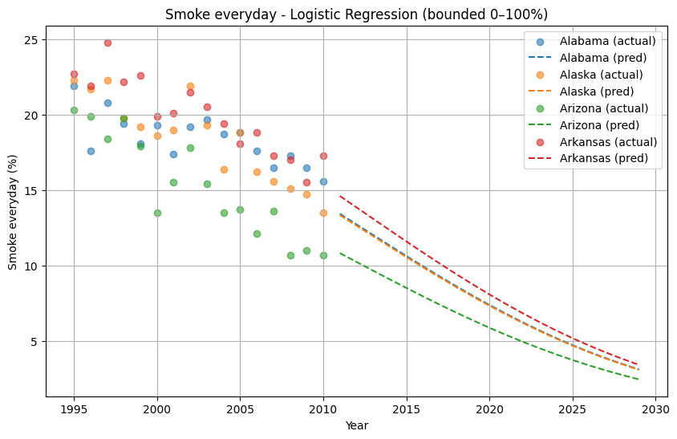

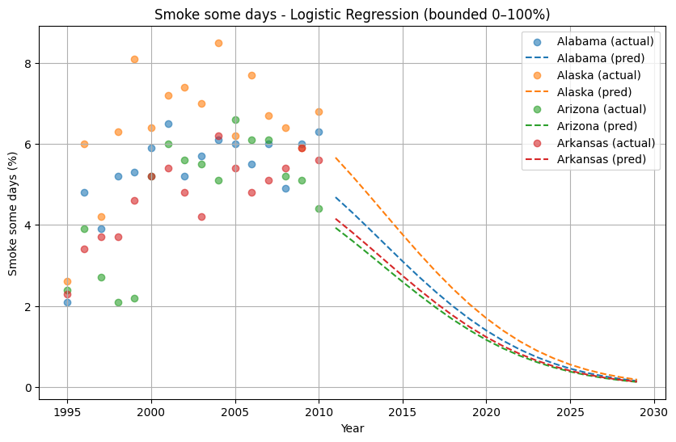

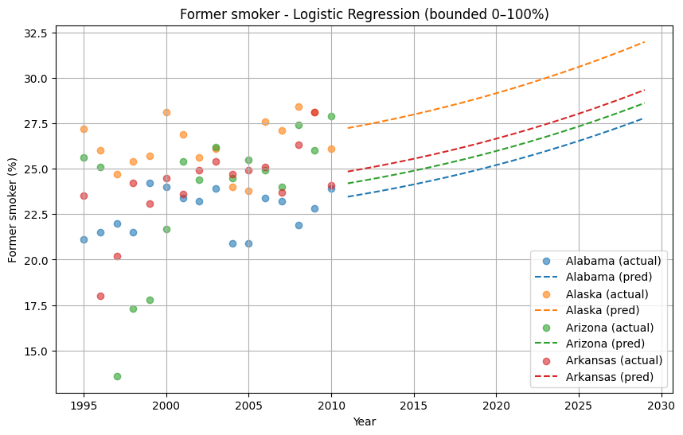

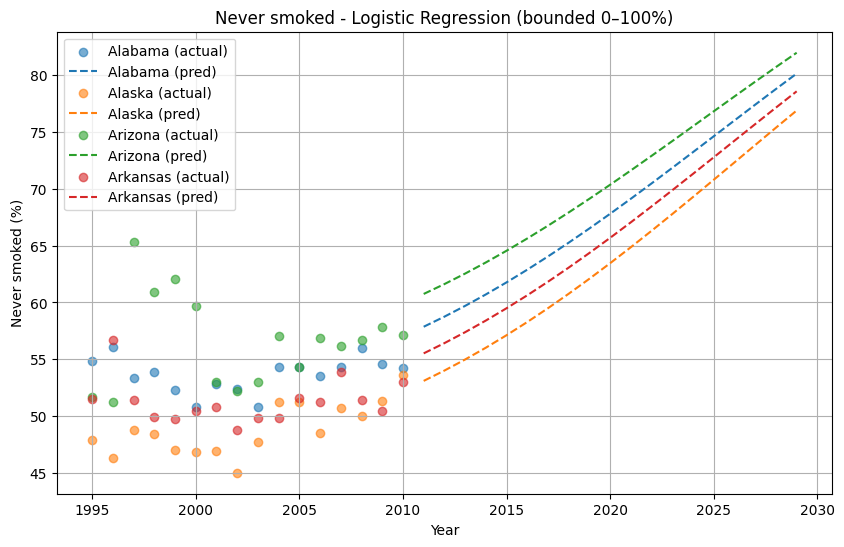

```python
# States to plot
plot_states = ['Alabama', 'Alaska', 'Arizona', 'Arkansas']

# --- Fit and predict ---
models = {}
future_predictions = future_df.copy()

for col in target_columns:
    # Apply logit transformation
    y_logit = logit(tobacco_clean[col].values)

    # Fit model on logit values
    model = LinearRegression()
    model.fit(X_combined, y_logit)
    models[col] = model

    # Predict and apply inverse logit
    y_pred_logit = model.predict(future_X_combined)
    y_pred = inv_logit(y_pred_logit) * 100  # convert back to %
    future_predictions[col] = y_pred

    # --- Plot ---
    plt.figure(figsize=(10, 6))
    for state in plot_states:
        # Historical
        df_hist = tobacco_clean[tobacco_clean['State'] == state]
        plt.scatter(df_hist['Year'], df_hist[col] * 100, label=f"{state} (actual)", alpha=0.6)

        # Future
        df_pred = future_predictions[future_predictions['State'] == state]
        plt.plot(df_pred['Year'], df_pred[col], label=f"{state} (pred)", linestyle='--')

    plt.title(f"{col} - Logistic Regression (bounded 0–100%)")
    plt.xlabel("Year")
    plt.ylabel(f"{col} (%)")
    plt.legend()
    plt.grid(True)
    plt.show()
```

We also want to test some specific cases to see what the model outputs, so we'll try Puerto Rico in 2025, Washington in 2020, and New York in 2015.

```python
# Define the custom test cases
test_cases = pd.DataFrame({
    'Year': [2025, 2020, 2015],
    'State': ['Puerto Rico', 'Washington', 'New York']
})
test_cases['Year2'] = test_cases['Year'] ** 2
test_encoded = encoder.transform(test_cases[['State']])
test_X_combined = pd.DataFrame(test_encoded, columns=state_columns)
test_X_combined['Year'] = test_cases['Year']
test_X_combined['Year2'] = test_cases['Year2']

# Predict and print
print("\n📦 Custom Example Predictions:\n")
for col in target_columns:
    logit_pred = models[col].predict(test_X_combined)
    prob_pred = inv_logit(logit_pred) * 100
    print(f"{col}:")
    for i, row in test_cases.iterrows():
        print(f"  {row['State']} ({row['Year']}): {prob_pred[i]:.2f}%")
    print()
```

```
📦 Custom Example Predictions:

Smoke everyday:
  Puerto Rico (2025): 2.01%
  Washington (2020): 5.68%
  New York (2015): 8.72%

Smoke some days:
  Puerto Rico (2025): 0.38%
  Washington (2020): 1.24%
  New York (2015): 2.98%

Former smoker:
  Puerto Rico (2025): 19.95%
  Washington (2020): 29.98%
  New York (2015): 26.52%

Never smoked:
  Puerto Rico (2025): 85.66%
  Washington (2020): 67.65%
  New York (2015): 62.58%
```

# Convert to html

```python
%%shell
jupyter nbconvert --to html /content/drive/MyDrive/ColabNotebooks/CMPS3160Project.ipynb
```

[output not shown]

[output cut: 136 more lines]

[output not shown]

[output not shown]